# Cx4073 : Assignment 3

# ———————————————————

# Step 3 : Data Preprocessing

# ———————————————————

Analyze the missing values in this dataset

```r
is.na(retailData)
```

[output not shown]

[output cut: 24986 more lines]

sum and the percentage of missing values in dataset

```r
sum(is.na(retailData))
```

```
## [1] 135080
```

```r
mean(is.na(retailData))
```

```
## [1] 0.03115837
```

omit records with missing values

```r
retailData <- na.omit(retailData)
```

Removing stock codes that are non-products

```r
retailData<-retailData[!(retailData$StockCode=="AMAZONFEE" | retailData$StockCode=="B" |
                           retailData$StockCode=="BANKCHARGES" | retailData$StockCode=="C2" |
                           retailData$StockCode=="CRUK" | retailData$StockCode=="D" |
                           retailData$StockCode=="DOT" | retailData$StockCode=="M" |
                           retailData$StockCode=="POST" | retailData$StockCode=="S"),]
```

Recheck dimension and summary of statistics

```r
dim(retailData)      # dimension of the dataset
```

```
## [1] 404925      8
```

```r
summary(retailData) # summary of the dataset
```

```
##    InvoiceNo        StockCode
##  576339 :   541   85123A :  2077
##  579196 :   532   22423  :  1905
##  580727 :   528   85099B :  1662
##  578270 :   441   84879  :  1418
##  573576 :   434   47566  :  1416
##  567656 :   420   20725  :  1359
##  (Other):402029   (Other):395088
##                              Description        Quantity
##  WHITE HANGING HEART T-LIGHT HOLDER:  2070   Min.   :-80995.00
##  REGENCY CAKESTAND 3 TIER          :  1905   1st Qu.:     2.00
##  JUMBO BAG RED RETROSPOT           :  1662   Median :     5.00
##  ASSORTED COLOUR BIRD ORNAMENT     :  1418   Mean   :    12.11
##  PARTY BUNTING                     :  1416   3rd Qu.:    12.00
##  LUNCH BAG RED RETROSPOT           :  1358   Max.   : 80995.00
##  (Other)                           :395096
##          InvoiceDate       UnitPrice         CustomerID
##  14/11/11 15:27:   541   Min.   :  0.000   Min.   :12346
##  28/11/11 15:54:   532   1st Qu.:  1.250   1st Qu.:13969
##  5/12/11 17:17 :   528   Median :  1.950   Median :15159
##  23/11/11 13:39:   442   Mean   :  2.901   Mean   :15295
##  31/10/11 14:09:   434   3rd Qu.:  3.750   3rd Qu.:16794
##  21/9/11 14:40 :   420   Max.   :649.500   Max.   :18287
##  (Other)       :402028
##            Country
##  United Kingdom:361271
##  Germany       :  9096
##  France        :  8168
##  EIRE          :  7380
##  Spain         :  2468
##  Netherlands   :  2330
##  (Other)       : 14212
```

# ———————————————————

# Step 4 : Deeper exploration of data

# ———————————————————

```r
counts <- table(retailData$Quantity)
cat("\nQuantity Distribution of retailData\n")
```

```
##
## Quantity Distribution of retailData
```

```r
counts
```

```
##
## -80995 -74215  -9360  -3114  -2000  -1930  -1515  -1300  -1296  -1200
##      1      1      1      1      1      1      1      1      2      1
##   -960   -840   -828   -756   -720   -701   -670   -624   -600   -576
##      1      1      1      1      3      1      1      1      2      2
##   -500   -480   -468   -432   -420   -408   -400   -360   -334   -324
##      1      1      1      3      1      1      2      3      1      1
##   -318   -312   -300   -288   -276   -252   -250   -244   -240   -234
##      1      1      2      6      1      1      4      1      7      1
##   -220   -200   -192   -186   -184   -180   -168   -164   -162   -160
##      1     12      6      1      1      3      1      1      1      3
##   -152   -150   -144   -140   -132   -130   -126   -121   -120   -113
##      1      2     26      2      1      2      1      1     18      1
##   -112   -110   -108   -100    -96    -94    -86    -85    -82    -80
##      1      3      3     50     21      1      1      1      1      2
```

[output cut: 74 more lines]

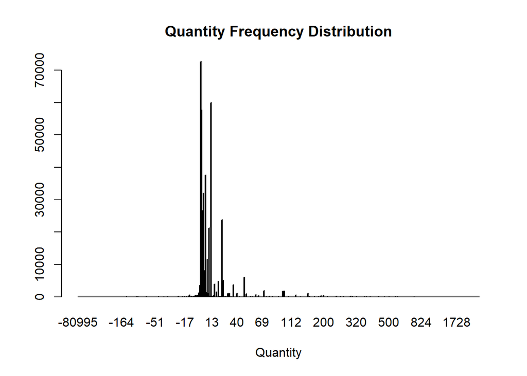

```r
b <- barplot(counts, main="Quantity Frequency Distribution",
             xlab="Quantity")
```

The graph shows that the most purchased quantity is 1 with a frequency of 72679. The majority of the distribution lies between quantities of 1 to 12. There are some quantities with a negative value and these are not valid in the interpretation as frequency should always be positive values.

```r
counts <- table(retailData$UnitPrice)
cat("\nUnitPrice Distribution\n")
```

```
##
## UnitPrice Distribution
```

```r
counts
```

```
##
##     0 0.001  0.03  0.04  0.06  0.07  0.08  0.09   0.1  0.11  0.12  0.14
##    34     4     1    66   112     9    46     2    52     1   637    89
##  0.16  0.17  0.18  0.19   0.2  0.21  0.22  0.24  0.25  0.27  0.28  0.29
##    45     8    25  1883    10  1128    11     5    59    16     3  4388
##   0.3  0.32  0.34  0.35  0.36  0.37  0.38  0.39   0.4  0.42   0.5  0.52
##    52    43    69     6   496     5   332  8169    29 22017    55     1
##  0.53  0.55  0.58  0.59  0.62  0.63  0.64  0.65  0.66  0.68  0.69   0.7
##    46  7514     4   204   107   282   139  7744     1     2    26     3
##  0.72  0.73  0.74  0.75  0.76  0.78  0.79   0.8  0.82  0.83  0.85  0.86
##  1235    13     3   593     2     1  2179     5   298  5987 26376     2
##   0.9  0.92  0.94  0.95  0.98     1  1.01  1.02  1.04  1.05  1.06  1.08
##     3     1     2  1417     1    79     1     1   276    49  1552    17
##   1.1  1.11  1.12  1.18  1.19  1.23  1.24  1.25  1.27  1.31  1.32  1.38
##     1     1    11     3    10     1     8 46531     7     1     1     7
##   1.4  1.43  1.45  1.46  1.48  1.49   1.5  1.53  1.55   1.6  1.63  1.64
##     2     3 12899     5    29   792    11    17   135     1   688     2
##  1.65  1.66  1.67  1.68  1.69   1.7  1.71  1.74  1.75  1.76  1.79   1.8
## 37493    21     1     1  4257    20     1    57    58     1  1229    13
##  1.85  1.86  1.88   1.9  1.92  1.93  1.95  1.96  1.97  1.98     2  2.04
##   752     1     5     1     9    11 12898     1     6     1     5     1
##  2.08   2.1  2.12  2.16  2.17  2.21  2.22  2.25  2.26   2.3  2.31  2.32
## 15945 17465    15     2    12     7     1  1073     2     2    33     6
##  2.33  2.35  2.39   2.4  2.41  2.42  2.46  2.48  2.49   2.5  2.55   2.6
##     1     1    21    19     9     1  1010     2  1251    22 12823     3
##  2.62  2.65  2.66  2.67  2.69  2.75  2.85  2.89  2.92  2.95  2.96  2.99
##     9     3    18     2     6   180     1  2707    26 27205     1     3
##     3  3.12  3.13  3.15  3.16   3.2  3.21  3.24  3.25  3.26  3.28  3.29
##     9     1     1     1     1    24    10    11  2151     6     3  1064
##   3.3  3.32  3.35  3.37  3.39   3.4  3.44  3.45  3.49   3.5  3.57  3.58
##     1    10   259    18   883     1     2   297     4     8     5     4
##  3.74  3.75  3.81  3.82  3.85  3.86  3.88  3.89   3.9  3.91  3.92  3.95
##     2 18087    48     3     1     3    15     2     4     3     1  2846
##  3.97  3.98     4  4.02  4.04  4.08  4.13  4.14  4.15  4.18  4.25  4.27
##     1     1     5     1     1     7   533     2  5757     5  7353     1
##   4.3  4.37   4.4   4.5  4.58   4.6  4.62  4.65  4.67  4.68   4.7  4.76
##     2     1     1     2    95    10     3   829     2     1     1     2
##  4.77  4.78   4.8  4.86  4.95  4.96  4.98     5  5.06  5.08   5.1  5.13
##     7     3    12     1 18648   120     2     3     3     2     7     1
##  5.14  5.15  5.17  5.18  5.32  5.35  5.39  5.45  5.49  5.55  5.64  5.66
```

[output cut: 10 more lines]

```
##     2   837    12     3     1     1     1  5756    16     4     7     2
## 10.39  10.4 10.65 10.75 10.79 10.95 11.15 11.63 11.67 11.95    12 12.46
##     3   142    23    87   125   993    25    25     2   145     1    67
## 12.48  12.5 12.75 12.95 12.98 13.29 13.35 14.13 14.55 14.95 14.96    15
##     2  1047  3744     1     1     6     1    15     7  1135     3    90
## 15.79 15.95 16.63 16.65 16.95 18.95 19.84 19.94 19.95 19.96    20  20.5
##    50   165    99    66  1255    13     1     1   111    10     1     1
##  20.8    21 21.95 24.95 24.96    25 26.95 29.13 29.95    30 32.69 32.95
##    21     1    32    77    27    71     3     3    54     1     1     4
## 33.29 34.95 35.75 35.95 39.95 41.75  42.5 42.95 49.95    50 52.77  57.6
##     3    28    11    41   138     6     1     1    25     3     1     3
## 57.95 59.95    65 79.95    85   110   125   145   165   175   195 265.5
##     2     6    13     1    32     6    64    12    23     2    12     1
##   295 649.5
##    10     2
```

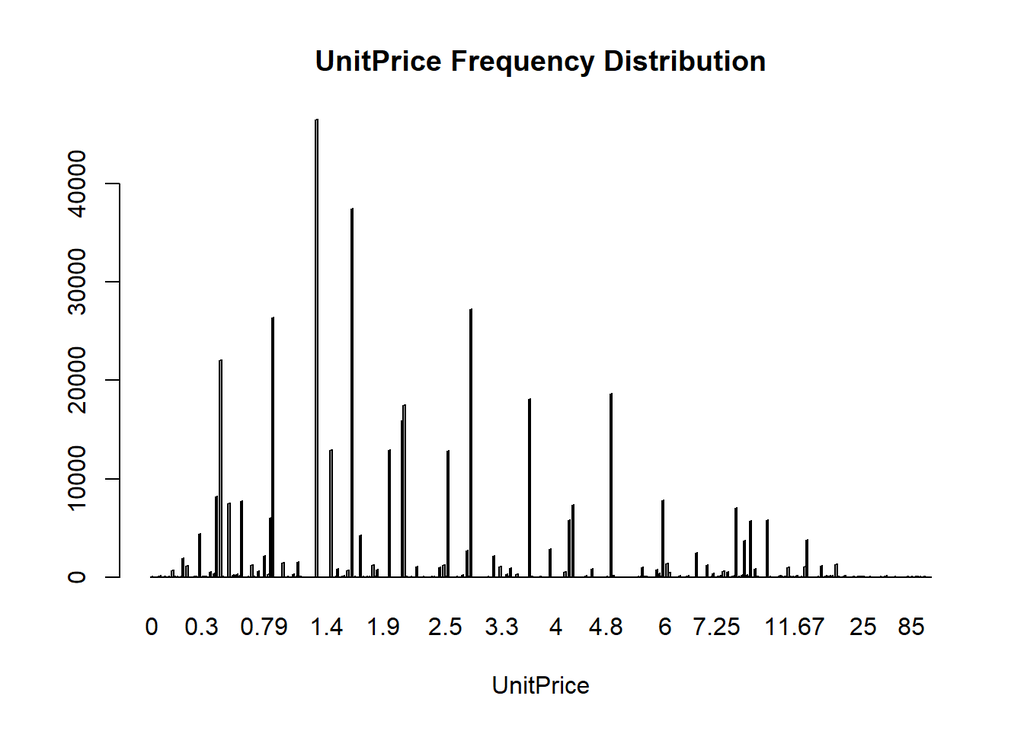

```r
b <- barplot(counts, main="UnitPrice Frequency Distribution",
             xlab="UnitPrice")
```

From the data, the highest frequency of Unitprice is 1.25.

```r
# install.packages("dplyr")
library("dplyr")
require(dplyr)
commonUP <- retailData[retailData$UnitPrice == 1.25,]
cat('\nTop 10 products for the common UnitPrice 1.25\n')
```

```
##
## Top 10 products for the common UnitPrice 1.25
```

```r
top10 <- commonUP %>% group_by(Description) %>% summarise(Quantity = sum(Quantity)) %>% arrange(desc(Quantity))
print(head(top10,10))
```

```
## # A tibble: 10 x 2
##    Description                        Quantity
##    <fct>                                 <int>
##  1 VICTORIAN GLASS HANGING T-LIGHT        7744
##  2 "RED  HARMONICA IN BOX "               7546
##  3 "DOUGHNUT LIP GLOSS "                  7522
##  4 SET OF 4 PANTRY JELLY MOULDS           7459
##  5 ICE CREAM SUNDAE LIP GLOSS             6788
##  6 ANTIQUE SILVER T-LIGHT GLASS           6721
##  7 "BLUE HARMONICA IN BOX "               6345
##  8 GROW A FLYTRAP OR SUNFLOWER IN TIN     5908
##  9 "ICE CREAM PEN LIP GLOSS "             5695
## 10 WOODEN BOX OF DOMINOES                 5327
```

```r
counts <- table(retailData$Country)
cat("\nCountry Distribution\n")
```

```
##
## Country Distribution
```

```r
counts
```

```
##
##            Australia              Austria              Bahrain
##                 1257                  387                   17
##              Belgium               Brazil               Canada
##                 1971                   32                  150
##      Channel Islands               Cyprus       Czech Republic
##                  753                  619                   28
##              Denmark                 EIRE   European Community
##                  375                 7380                   58
##              Finland               France              Germany
##                  653                 8168                 9096
##               Greece            Hong Kong              Iceland
##                  142                    0                  182
##               Israel                Italy                Japan
##                  250                  783                  355
##              Lebanon            Lithuania                Malta
##                   45                   35                  123
##          Netherlands               Norway               Poland
##                 2330                 1060                  336
##             Portugal                  RSA         Saudi Arabia
##                 1436                   57                   10
##            Singapore                Spain               Sweden
##                  215                 2468                  437
##          Switzerland United Arab Emirates       United Kingdom
##                 1844                   67               361271
##          Unspecified                  USA
##                  244                  291
```

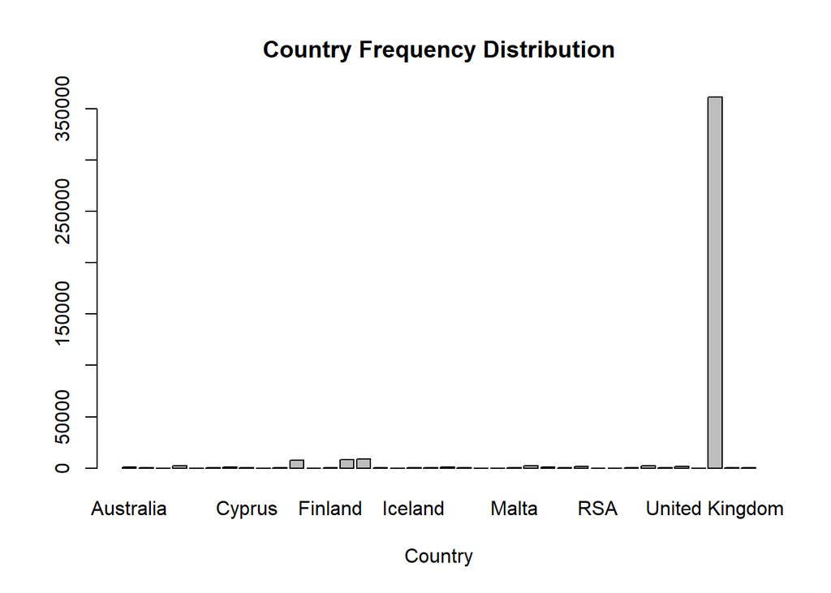

```r
b <- barplot(counts, main="Country Frequency Distribution",
             xlab="Country")
```

From observations the Country distribution is highly skewed towards the United Kingdom(UK). Most of the purchases were done in UK and as such this would not be an important factor to consider while analysing the clusters

Introducing New variable : Invoice Year

```r
retailData$InvoiceYear <- format(as.Date(retailData$InvoiceDate, format="%d/%m/%Y %H:%M"),"%Y")
retailData$InvoiceYear <- as.numeric(retailData$InvoiceYear)
retailData$InvoiceYear[retailData$InvoiceYear < 2000 ] <- (retailData$InvoiceYear[retailData$InvoiceYear < 2000] + 2000)

counts <- table(retailData$InvoiceYear)
cat("\nInvoiceYear Distribution\n")
```

```
##
## InvoiceYear Distribution
```

```r
counts
```

```
##
##   2010   2011
##  26735 378190
```

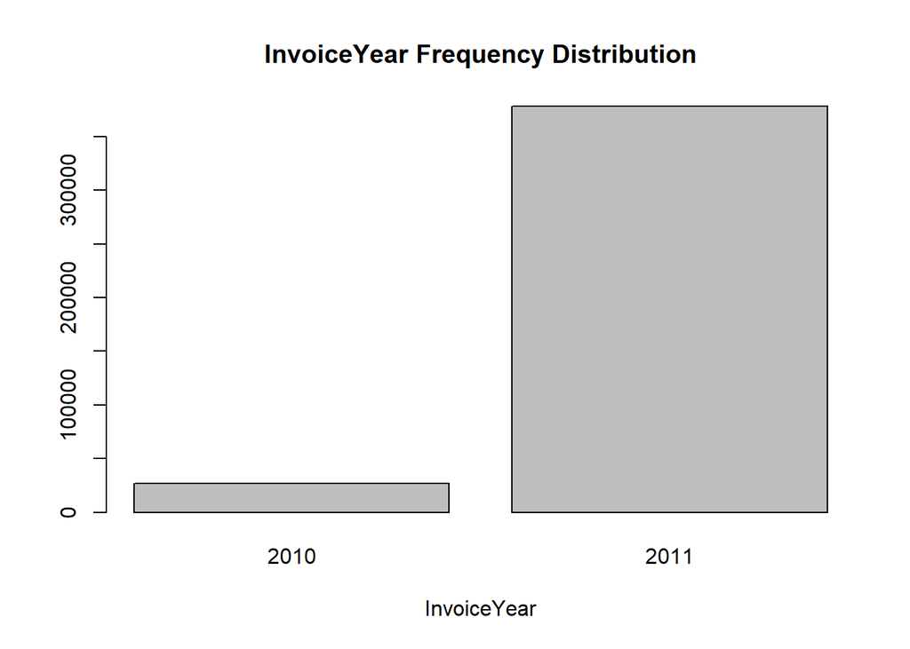

```r
b <- barplot(counts, main="InvoiceYear Frequency Distribution",
             xlab="InvoiceYear")
```

As seen in the bar plot, majority of the Invoices in this data are from the year 2011

Introducing New variable : Invoice Month

```r
retailData$InvoiceMonth <- format(as.Date(retailData$InvoiceDate, format="%d/%m/%Y %H:%M"),"%m")
retailData$InvoiceMonth <- as.numeric(retailData$InvoiceMonth)

counts <- table(retailData$InvoiceMonth)
cat("\nInvoiceMonth Distribution\n")
```

```
##
## InvoiceMonth Distribution
```

```r
counts
```

```
##
##     1     2     3     4     5     6     7     8     9    10    11    12
## 21808 20266 27666 23088 28762 27708 27360 27519 40632 50474 65317 44325
```

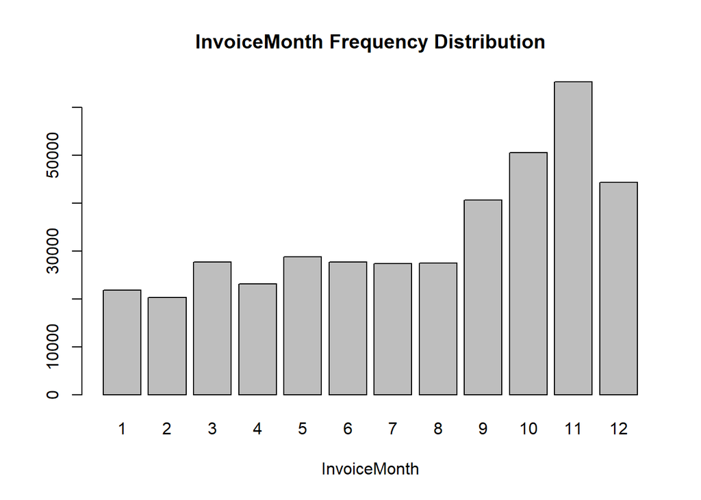

```r
b <- barplot(counts, main="InvoiceMonth Frequency Distribution",
             xlab="InvoiceMonth")
```

As seen in the bar plot, the months nearer to the end of the year have a higher frequency due # to festive periods and the willingness to splurge.

Introducing New variable : InvoiceDay which is Day of a week

```r
retailData$InvoiceDay <- weekdays(as.Date(retailData$InvoiceDate))

counts <- table(retailData$InvoiceDay)
cat("\nInvoiceDay Distribution\n")
```

```
##
## InvoiceDay Distribution
```

```r
counts
```

```
##
##    Friday    Monday  Saturday    Sunday  Thursday   Tuesday Wednesday
##     53473     57599     58272     59734     56503     59257     60087
```

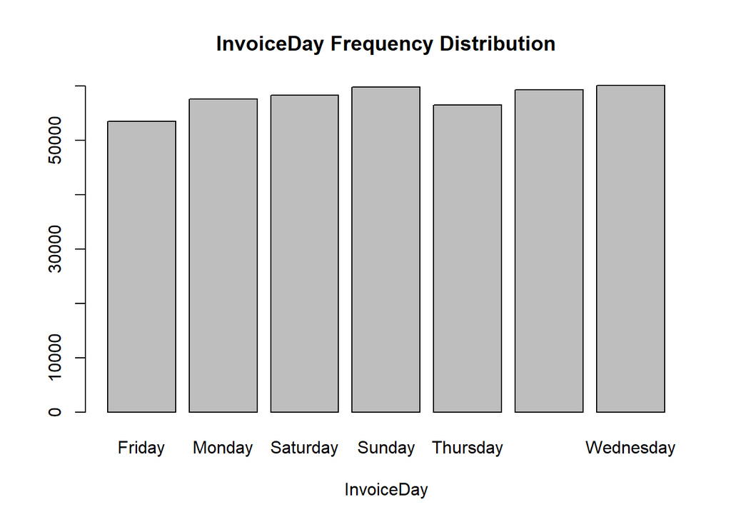

```r
b <- barplot(counts, main="InvoiceDay Frequency Distribution",
             xlab="InvoiceDay")
```

As seen in the bar plot, InvoiceDay had a relatively uniform distribution.

# Hypothesis:

We predict that the greatest number of items sold will be largely party items. This is because as per our analysis most items were sold in towards the end of the year and school holidays will begin towards the end of year. Moreover, from our analysis most items were sold in United Kingdom. Towards the end of the year, commences Christmas in UK, their largest festival. Thus, we believe that the items sold in greatest numbers will be Christmas party items.

# ———————————————————

# Step 5 : create matrix with values of Quantity

# ——————————————————-

```r
retailData$CustomerID <- as.factor(retailData$CustomerID)

Quantity_matrix <- xtabs(Quantity ~ CustomerID + StockCode, data = retailData, addNA = TRUE, sparse = TRUE)
```

Removing unnecessary variables

```r
retailData <- subset(retailData, select = -c(InvoiceDate,Country) )
head(retailData)
```

```
##   InvoiceNo StockCode                         Description Quantity
## 1    536365    85123A  WHITE HANGING HEART T-LIGHT HOLDER        6
## 2    536365     71053                 WHITE METAL LANTERN        6
## 3    536365    84406B      CREAM CUPID HEARTS COAT HANGER        8
## 4    536365    84029G KNITTED UNION FLAG HOT WATER BOTTLE        6
## 5    536365    84029E      RED WOOLLY HOTTIE WHITE HEART.        6
## 6    536365     22752        SET 7 BABUSHKA NESTING BOXES        2
##   UnitPrice CustomerID InvoiceYear InvoiceMonth InvoiceDay
## 1      2.55      17850        2010           12     Monday
## 2      3.39      17850        2010           12     Monday
## 3      2.75      17850        2010           12     Monday
## 4      3.39      17850        2010           12     Monday
## 5      3.39      17850        2010           12     Monday
## 6      7.65      17850        2010           12     Monday
```

We removed InvoiceDate as we are using the 3 newly introduced variables of the date component and country is mostly involving UK.

Adding numeric variables to apply clustering methods

```r
retailData$InvoiceNo_num <- as.numeric(retailData$InvoiceNo)
retailData$StockCode_num <- as.numeric(retailData$StockCode)
retailData$Description_num <- as.numeric(retailData$Description)
retailData$Quantity_num <- as.numeric(retailData$Quantity)
retailData$UnitPrice_num <- as.numeric(retailData$UnitPrice)
retailData$CustomerID_num <- as.numeric(retailData$CustomerID)
retailData$InvoiceYear_num <- as.numeric(retailData$InvoiceYear)
retailData$InvoiceMonth_num <- as.numeric(retailData$InvoiceMonth)
retailData$InvoiceDay_num <- as.numeric(as.factor(retailData$InvoiceDay))
```

Choose only numeric variables to input into clustering methods

```r
numericDF <- retailData[c(10:18)]
head(numericDF)
```

```
##   InvoiceNo_num StockCode_num Description_num Quantity_num UnitPrice_num
## 1             1          3538            4027            6          2.55
## 2             1          2795            4035            6          3.39
## 3             1          3045             932            8          2.75
## 4             1          2986            1959            6          3.39
## 5             1          2985            2980            6          3.39
## 6             1          1663            3235            2          7.65
##   CustomerID_num InvoiceYear_num InvoiceMonth_num InvoiceDay_num
## 1           4040            2010               12              2
## 2           4040            2010               12              2
## 3           4040            2010               12              2
## 4           4040            2010               12              2
## 5           4040            2010               12              2
## 6           4040            2010               12              2
```

# ———————————————————

# Step 6 : Identify clusters in their customer base & choosing the right distance of clustering

# ——————————————————-

# 6.1 Hierarchical Clustering :

Using this clustering method to build the dendogram and analyse how many clusters or K is required. Using method ward to check for compact sperical clusters.

```r
#hiercFit <- hclust(dist(numericDF, method = "euclidean"), method="ward.D")
#hiercFit
```

Hierarchical Clustering cannot accept such a huge vector input size as data size is huge, therefore hierarchical clustering is not efficient for this case.

# 6.2 Perform K-Means Clustering with K determined

Finding the optimal K value for clustering via K-Means.Running through different values of K, and visualize where the optimal value could lie.

```r
kMin <- 1
kMax <- 20
withinSS <- double(kMax - kMin + 1)
betweenSS <- double(kMax - kMin + 1)

for (K in kMin:kMax) {
  kMeansFit <- kmeans(numericDF, centers = K, nstart = 20)
  withinSS[K] <- sum(kMeansFit$withinss)
  betweenSS[K] <- kMeansFit$betweenss
}
```

[output not shown]

[output cut: 58 more lines]

[output not shown]

[output not shown]

[output not shown]

[output not shown]

Visualizing the Between and Within Sum of Square to look for an elbow point, the optimal value of K

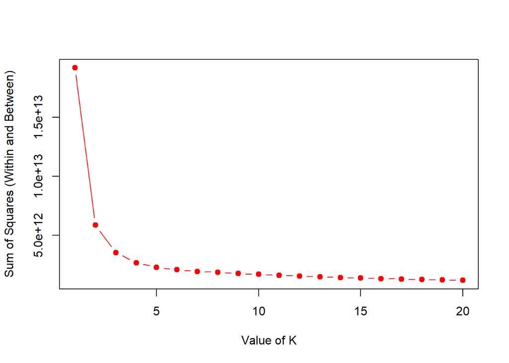

```r
plot(kMin:kMax, withinSS, pch=19, type="b", col="red",
     xlab = "Value of K", ylab = "Sum of Squares (Within and Between)")
```

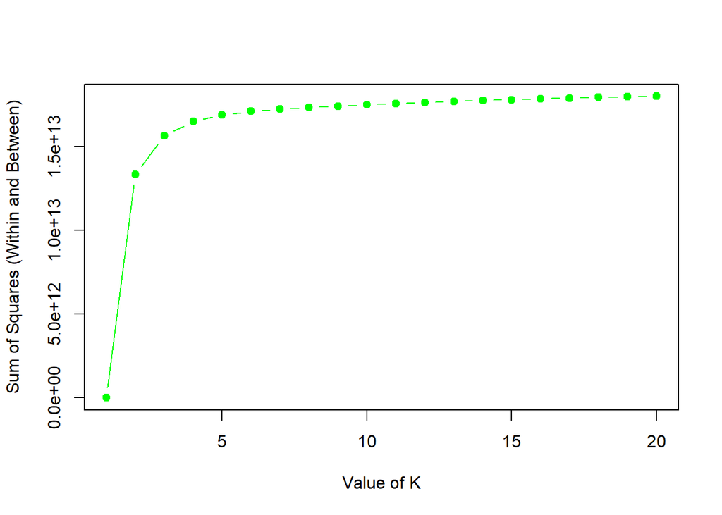

```r
plot(kMin:kMax, betweenSS, pch=19, type="b", col="green",
     xlab = "Value of K", ylab = "Sum of Squares (Within and Between)")
```

The only elbow point that could be visualized from the two plots is at K = 4. Optimal K = 4 using the elbow point method

# 6.3 Perform EM Clustering on the dataset

```r
# install.packages("mclust")
#library(mclust)
#emFit <- Mclust(numericDF)
#cat("\nSummary of EM clustering method\n")
#summary(emFit)
```

# ——————————————————-

# Clustering with observed optimal K = 4

# ——————————————————-

# Calculating Quantity distribution to understand importance

kMeansFit using optimal k value =4

```r
K <- 4
kMeansFit <- kmeans(numericDF, centers = K, nstart = 20)
cat("Structure of kMeans clustering method for K = ",K)
```

```
## Structure of kMeans clustering method for K =  4
```

```r
str(kMeansFit)
```

```
## List of 9
##  $ cluster     : Named int [1:404925] 1 1 1 1 1 1 1 1 1 1 ...
##   ..- attr(*, "names")= chr [1:404925] "1" "2" "3" "4" ...
##  $ centers     : num [1:4, 1:9] 3038 14979 20171 9133 1539 ...
##   ..- attr(*, "dimnames")=List of 2
##   .. ..$ : chr [1:4] "1" "2" "3" "4"
##   .. ..$ : chr [1:9] "InvoiceNo_num" "StockCode_num" "Description_num" "Quantity_num" ...
##  $ totss       : num 1.92e+13
##  $ withinss    : num [1:4] 6.83e+11 6.70e+11 6.97e+11 6.34e+11
##  $ tot.withinss: num 2.69e+12
##  $ betweenss   : num 1.65e+13
##  $ size        : int [1:4] 98856 109818 101995 94256
##  $ iter        : int 2
##  $ ifault      : int 0
##  - attr(*, "class")= chr "kmeans"
```

output of kMeans clustering

```r
out <- cbind(numericDF, clusterNum=kMeansFit$cluster)


# Merging back numeric variables into original factor variables to further observe patterns
clustDF <- merge(retailData, out, by = c("InvoiceNo_num","StockCode_num","Description_num","Quantity_num","UnitPrice_num",
                                         "CustomerID_num","InvoiceYear_num","InvoiceMonth_num","InvoiceDay_num"), all.x = TRUE)
cat("\nRetail data sample observation\n")
```

```
##
## Retail data sample observation
```

```r
#write.csv(clustDF,file="assign3_clusterDataK4.csv",append=FALSE,row.names=FALSE,sep=",")
clustDF <- read.csv("assign3_clusterDataK4.csv", header = TRUE)
head(clustDF)
```

```
##   InvoiceNo_num StockCode_num Description_num Quantity_num UnitPrice_num
## 1             1          1663            3235            2          7.65
## 2             1          2795            4035            6          3.39
## 3             1          2985            2980            6          3.39
## 4             1          2986            1959            6          3.39
## 5             1          3045             932            8          2.75
## 6             1          3538            4027            6          2.55
##   CustomerID_num InvoiceYear_num InvoiceMonth_num InvoiceDay_num InvoiceNo
## 1           4040            2010               12              2    536365
## 2           4040            2010               12              2    536365
## 3           4040            2010               12              2    536365
## 4           4040            2010               12              2    536365
## 5           4040            2010               12              2    536365
## 6           4040            2010               12              2    536365
##   StockCode                         Description Quantity UnitPrice
## 1     22752        SET 7 BABUSHKA NESTING BOXES        2      7.65
## 2     71053                 WHITE METAL LANTERN        6      3.39
## 3    84029E      RED WOOLLY HOTTIE WHITE HEART.        6      3.39
## 4    84029G KNITTED UNION FLAG HOT WATER BOTTLE        6      3.39
## 5    84406B      CREAM CUPID HEARTS COAT HANGER        8      2.75
## 6    85123A  WHITE HANGING HEART T-LIGHT HOLDER        6      2.55
##   CustomerID InvoiceYear InvoiceMonth InvoiceDay clusterNum
## 1      17850        2010           12     Monday          2
## 2      17850        2010           12     Monday          2
## 3      17850        2010           12     Monday          2
## 4      17850        2010           12     Monday          2
## 5      17850        2010           12     Monday          2
## 6      17850        2010           12     Monday          2
```

# ——————————————————-

# Step 7: Market Segmentation

# ——————————————————-

Analysing each cluster Drawing of bar plots to visualise the distribution of variables in each cluster

Analyses the Quantity, UnitPrice variables in every cluster by obtaining the mean value from every cluster

Table and bar plots are plotted to see the distribution of Quantity, UnitPrice, InvoiceYear, InvoiceMonth, InvoiceDay variables

Also, the top10 products bought by customers in every cluster is displayed and analysed below

```r
cat("\nComparing Quantity mean for different clusters\n")
```

```
##
## Comparing Quantity mean for different clusters
```

```r
z = tapply(clustDF$Quantity, clustDF$cluster, mean)
print(z)
```

```
##         1         2         3         4
## 12.932399 13.198946 13.411467  7.857057
```

Clusters 1,2,3 have similar means for Quantity while Cluster 4’s mean varies from the rest.

```r
cat("\nComparing UnitPrice mean for different clusters\n")
```

```
##
## Comparing UnitPrice mean for different clusters
```

```r
z = tapply(clustDF$UnitPrice, clustDF$cluster, mean)
print(z)
```

```
##        1        2        3        4
## 2.948370 3.041381 2.770826 2.813008
```

All Clusters have similar means for UnitPrice.

Analysing distributions in every cluster

```r
cat("\nQuantity distribution comparison per cluster\n")
```

```
##
## Quantity distribution comparison per cluster
```

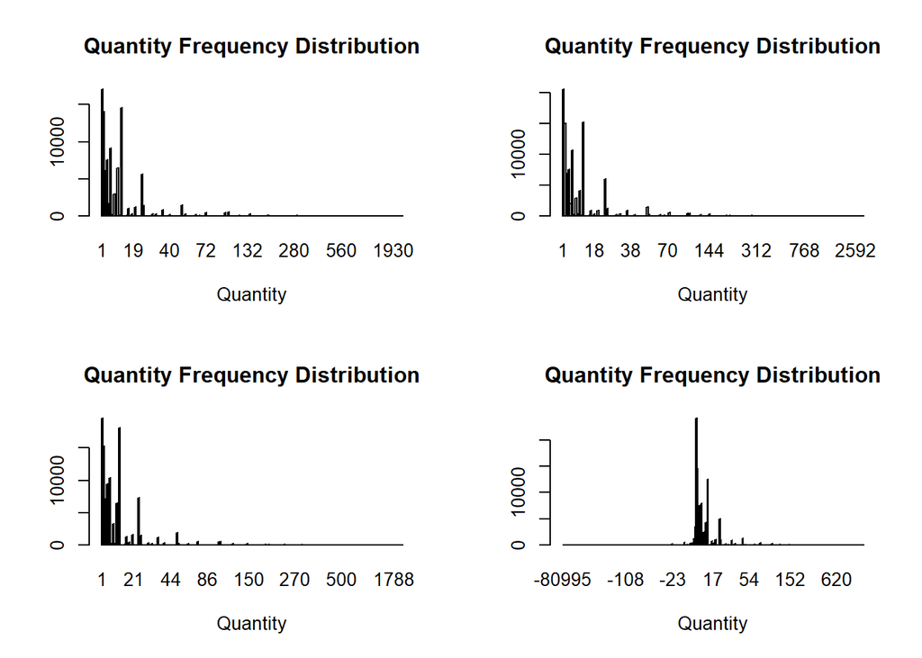

```r
par(mfrow=c(2,2))
clustlabel<- 1
while(clustlabel<5){
  clust <- clustDF[clustDF$clusterNum == clustlabel,]

  counts <- table(clust$Quantity)

  b <- barplot(counts, main="Quantity Frequency Distribution",
               xlab="Quantity")
  clustlabel<-clustlabel+1
}
```

```r
par(mfrow=c(1,1))
```

```r
cat("\nUnitPrice distribution comparison per cluster\n")
```

```
##
## UnitPrice distribution comparison per cluster
```

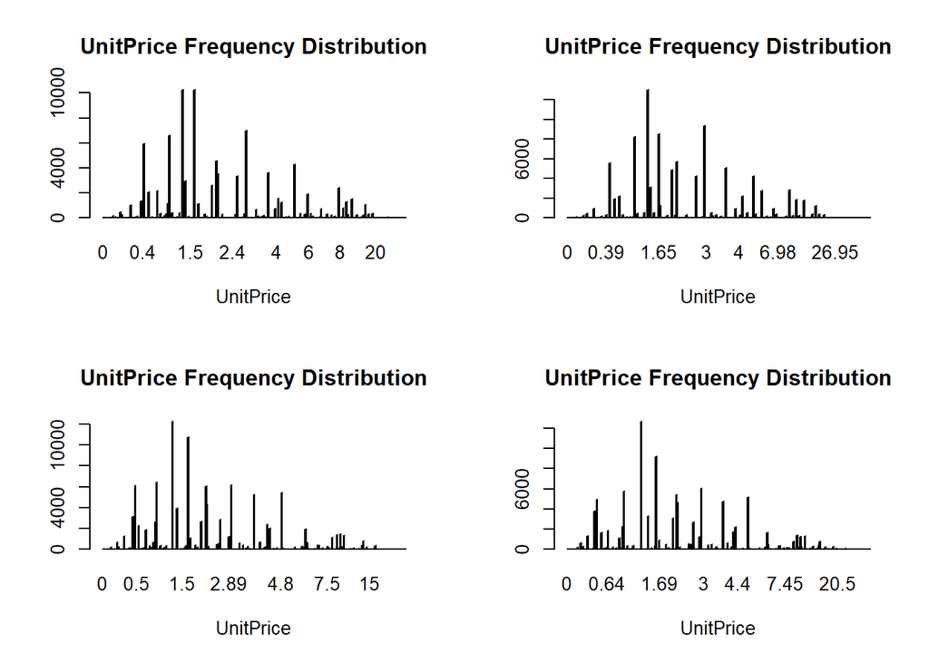

```r
par(mfrow=c(2,2))
clustlabel<- 1
while(clustlabel<5){

  clust <- clustDF[clustDF$clusterNum ==clustlabel,]

  counts <- table(clust$UnitPrice)

  b <- barplot(counts, main="UnitPrice Frequency Distribution",
               xlab="UnitPrice")

  clustlabel<-clustlabel+1

}
```

```r
par(mfrow=c(1,1))
```

The UnitPrice is evenly distributed in all the 4 clusters as supported by the summary statistics # earlier. The common UnitPrice among the clusters seems to be 1.25

```r
cat("\nInvoiceYear distribution comparison per cluster\n")
```

```
##
## InvoiceYear distribution comparison per cluster
```

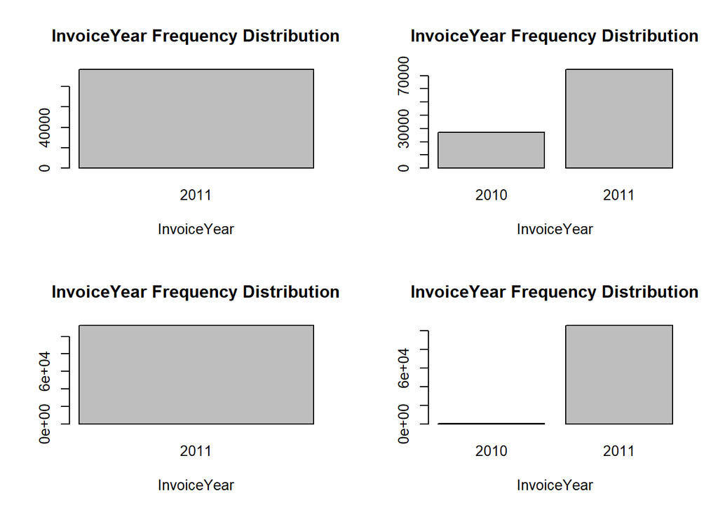

```r
par(mfrow=c(2,2))
clustlabel<- 1
while(clustlabel<5){

  clust <- clustDF[clustDF$clusterNum ==clustlabel,]

  counts <- table(clust$InvoiceYear)

  b <- barplot(counts, main="InvoiceYear Frequency Distribution",
               xlab="InvoiceYear")

  clustlabel<-clustlabel+1

}
```

```r
par(mfrow=c(1,1))
```

Clusters 1 and 3 contain data from 2011 only, whereas Clusters 2 and 4 have a mixture of data from 2010 and 2011 too. Cluster 2 has a greater number of invoices from 2010 in comparison to Cluster 4.

```r
cat("\nInvoiceMonth distribution comparison per cluster\n")
```

```
##
## InvoiceMonth distribution comparison per cluster
```

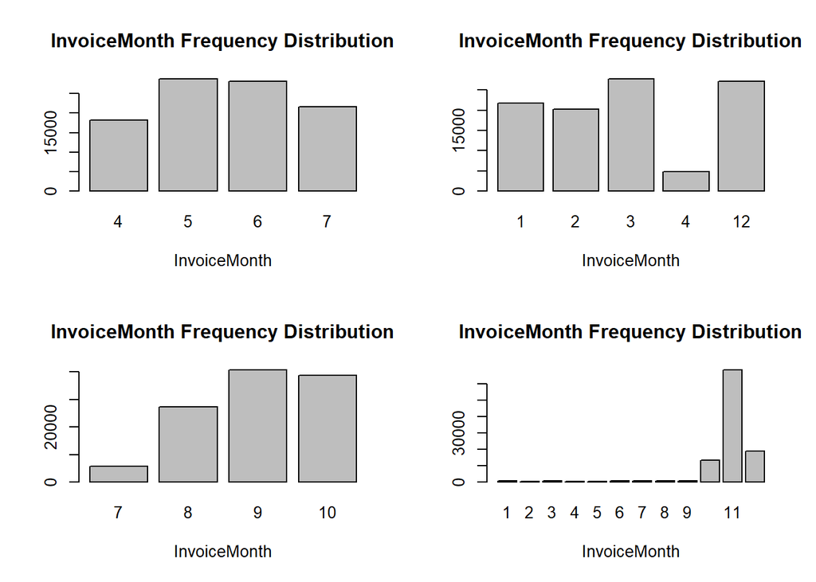

```r
par(mfrow=c(2,2))
clustlabel<- 1
while(clustlabel<5){

  clust <- clustDF[clustDF$clusterNum ==clustlabel,]

  counts <- table(clust$InvoiceMonth)

  b <- barplot(counts, main="InvoiceMonth Frequency Distribution",
               xlab="InvoiceMonth")

  clustlabel<-clustlabel+1

}
```

```r
par(mfrow=c(1,1))
```

The distribution here is pretty interesting as there is no common pattern here and the individual clusters can be seen. Cluster 2 shows high frequency in December, January, February and March. However it does # have some overlaps with Cluster 1 for the month of April for some points. Cluster 1 shows high frequency in April, May, June, July. Cluster 3 shows high frequency in August, September, October. However it does have overlaps with Cluster 1 for the month of July for some points. Cluster 4 shows highest frequency in November. However it does have overlaps with Cluster 3 and 2 for the month of October and December respectively.The overlaps could be the points that lie in between the clusters and other factors need to be taken in consideration as well.

```r
cat("\nInvoiceDay distribution comparison per cluster\n")
```

```
##
## InvoiceDay distribution comparison per cluster
```

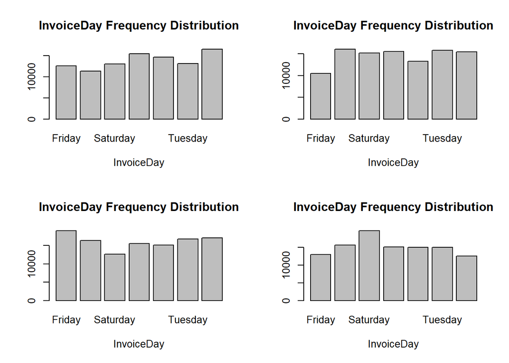

```r
par(mfrow=c(2,2))
clustlabel<- 1
while(clustlabel<5){

  clust <- clustDF[clustDF$clusterNum ==clustlabel,]

  counts <- table(clust$InvoiceDay)

  b <- barplot(counts, main="InvoiceDay Frequency Distribution",
               xlab="InvoiceDay")

  clustlabel<-clustlabel+1

}
```

```r
par(mfrow=c(1,1))
```

The frequency of purchases is somewhat uniquely distributed in all the clusters.

There are different days with the highest frequency in each of the clusters.

Cluster 1: Wednesday

Cluster 2: Monday

Cluster 3: Friday

Cluster 4: Saturday

All in all, the month and the day help to easily identify which cluster the data point is likely to be clustered. They have proven to be strong variables to separate clusters.

Top 10 products in every cluster

```r
# install.packages("dplyr")
library("dplyr")
require(dplyr)

clustlabel<- 1
while (clustlabel<5){
  clust <- clustDF[clustDF$clusterNum ==clustlabel,]
  cat('\nTop 10 products bought by the customers by quantity in cluster',clustlabel,'\n')
  top10 <- clust %>% group_by(Description) %>% summarise(Quantity = sum(Quantity)) %>% arrange(desc(Quantity))
  print(head(top10,10))
  clustlabel <- clustlabel +1
}
```

```
##
## Top 10 products bought by the customers by quantity in cluster 1
## # A tibble: 10 x 2
##    Description                         Quantity
##    <fct>                                  <int>
##  1 WORLD WAR 2 GLIDERS ASSTD DESIGNS      16944
##  2 ASSORTED COLOURS SILK FAN              11632
##  3 WHITE HANGING HEART T-LIGHT HOLDER     11038
##  4 JUMBO BAG RED RETROSPOT                10914
##  5 PACK OF 60 PINK PAISLEY CAKE CASES      9523
##  6 SMALL POPCORN HOLDER                    9203
##  7 PACK OF 72 RETROSPOT CAKE CASES         8926
##  8 PARTY BUNTING                           8299
##  9 COLOUR GLASS T-LIGHT HOLDER HANGING     8000
## 10 ASSORTED COLOUR BIRD ORNAMENT           7725
##
## Top 10 products bought by the customers by quantity in cluster 2
## # A tibble: 10 x 2
##    Description                        Quantity
##    <fct>                                 <int>
##  1 MEDIUM CERAMIC TOP STORAGE JAR        74215
##  2 WORLD WAR 2 GLIDERS ASSTD DESIGNS     16900
##  3 JUMBO BAG RED RETROSPOT               13322
##  4 WHITE HANGING HEART T-LIGHT HOLDER    13187
##  5 PACK OF 72 RETROSPOT CAKE CASES       13072
##  6 "PACK OF 12 LONDON TISSUES "          10744
##  7 SMALL POPCORN HOLDER                   8823
##  8 ASSORTED COLOUR BIRD ORNAMENT          8703
##  9 GROW A FLYTRAP OR SUNFLOWER IN TIN     8403
## 10 "MINI PAINT SET VINTAGE "              8245
##
## Top 10 products bought by the customers by quantity in cluster 3
## # A tibble: 10 x 2
##    Description                       Quantity
##    <fct>                                <int>
##  1 JUMBO BAG RED RETROSPOT              15062
##  2 POPCORN HOLDER                       12197
##  3 ASSORTED COLOUR BIRD ORNAMENT        11869
##  4 WORLD WAR 2 GLIDERS ASSTD DESIGNS     9750
##  5 "GIRLS ALPHABET IRON ON PATCHES "     8928
##  6 PACK OF 72 RETROSPOT CAKE CASES       8550
##  7 "RED  HARMONICA IN BOX "              7993
##  8 60 CAKE CASES VINTAGE CHRISTMAS       7889
##  9 "MINI PAINT SET VINTAGE "             7598
## 10 JUMBO BAG PINK POLKADOT               7570
##
## Top 10 products bought by the customers by quantity in cluster 4
## # A tibble: 10 x 2
##    Description                         Quantity
##    <fct>                                  <int>
##  1 RABBIT NIGHT LIGHT                     21970
##  2 POPCORN HOLDER                         16102
##  3 ASSTD DESIGN 3D PAPER STICKERS         12591
##  4 WORLD WAR 2 GLIDERS ASSTD DESIGNS       9813
##  5 "PAPER CHAIN KIT 50'S CHRISTMAS "       7256
##  6 ASSORTED COLOUR BIRD ORNAMENT           7215
##  7 DISCO BALL CHRISTMAS DECORATION         6635
##  8 WOODEN STAR CHRISTMAS SCANDINAVIAN      6344
##  9 JUMBO BAG RED RETROSPOT                 5974
## 10 WOODEN HEART CHRISTMAS SCANDINAVIAN     5787
```

Items that have been purchased the most in every cluster:

Cluster1: WORLD WAR 2 GLIDERS ASSTD DESIGNS Quantity = 16944

Cluster2: MEDIUM CERAMIC TOP STORAGE JAR Quantity = 74215

Cluster3: JUMBO BAG RED RETROSPOT Quantity = 15062

Cluster4: RABBIT NIGHT LIGHT Quantity = 21970

We notice that WORLD WAR 2 GLIDERS ASSTD DESIGNS appears 1st in Cluster1, # 2nd in Cluster2, 4th in Cluster3, 4th in Cluster4. WORLD WAR 2 GLIDERS ASSTD DESIGNS appears within Top5 in all Clusters. We also notice that JUMBO BAG RED RETROSPOT appears 4th in Cluster1,3rd in Cluster2, 1st in Cluster3, 9th in Cluster4. JUMBO BAG RED RETROSPOT appears within Top10 in all Clusters. Hence,we conclude that WORLD WAR 2 GLIDERS ASSTD DESIGNS and JUMBO BAG RED RETROSPOT are the most well-liked products overall. Thus, one marketing strategy would be to replenish these stocks frequently and ensure they  
are always available.

Introducing new variable Sales = Quantity * UnitPrice

```r
clustDF$Sales <- clustDF$Quantity * clustDF$UnitPrice
head(clustDF)
```

```
##   InvoiceNo_num StockCode_num Description_num Quantity_num UnitPrice_num
## 1             1          1663            3235            2          7.65
## 2             1          2795            4035            6          3.39
## 3             1          2985            2980            6          3.39
## 4             1          2986            1959            6          3.39
## 5             1          3045             932            8          2.75
## 6             1          3538            4027            6          2.55
##   CustomerID_num InvoiceYear_num InvoiceMonth_num InvoiceDay_num InvoiceNo
## 1           4040            2010               12              2    536365
## 2           4040            2010               12              2    536365
## 3           4040            2010               12              2    536365
## 4           4040            2010               12              2    536365
## 5           4040            2010               12              2    536365
## 6           4040            2010               12              2    536365
##   StockCode                         Description Quantity UnitPrice
## 1     22752        SET 7 BABUSHKA NESTING BOXES        2      7.65
## 2     71053                 WHITE METAL LANTERN        6      3.39
## 3    84029E      RED WOOLLY HOTTIE WHITE HEART.        6      3.39
## 4    84029G KNITTED UNION FLAG HOT WATER BOTTLE        6      3.39
## 5    84406B      CREAM CUPID HEARTS COAT HANGER        8      2.75
## 6    85123A  WHITE HANGING HEART T-LIGHT HOLDER        6      2.55
##   CustomerID InvoiceYear InvoiceMonth InvoiceDay clusterNum Sales
## 1      17850        2010           12     Monday          2 15.30
## 2      17850        2010           12     Monday          2 20.34
## 3      17850        2010           12     Monday          2 20.34
## 4      17850        2010           12     Monday          2 20.34
## 5      17850        2010           12     Monday          2 22.00
## 6      17850        2010           12     Monday          2 15.30
```

```r
clustlabel<- 1
while (clustlabel<5){
  clust <- clustDF[clustDF$clusterNum ==clustlabel,]
  cat('\nTop 10 products bought by the customers by Sales in cluster',clustlabel,'\n')
  top10 <- clust %>% group_by(Description) %>% summarise(Sales = sum(Sales)) %>% arrange(desc(Sales))
  print(head(top10,10))

  clustlabel <- clustlabel +1
}
```

```
##
## Top 10 products bought by the customers by Sales in cluster 1
## # A tibble: 10 x 2
##    Description                         Sales
##    <fct>                               <dbl>
##  1 PICNIC BASKET WICKER 60 PIECES     39620.
##  2 REGENCY CAKESTAND 3 TIER           39250.
##  3 PARTY BUNTING                      37142.
##  4 WHITE HANGING HEART T-LIGHT HOLDER 29641.
##  5 JUMBO BAG RED RETROSPOT            20639.
##  6 SPOTTY BUNTING                     18062.
##  7 DOORMAT KEEP CALM AND COME IN      13861.
##  8 ASSORTED COLOUR BIRD ORNAMENT      12786.
##  9 "REGENCY TEAPOT ROSES "            12171
## 10 JUMBO BAG APPLES                   11648.
##
## Top 10 products bought by the customers by Sales in cluster 2
## # A tibble: 10 x 2
##    Description                          Sales
##    <fct>                                <dbl>
##  1 MEDIUM CERAMIC TOP STORAGE JAR      77184.
##  2 REGENCY CAKESTAND 3 TIER            55129.
##  3 WHITE HANGING HEART T-LIGHT HOLDER  35779.
##  4 JUMBO BAG RED RETROSPOT             23197.
##  5 CHILLI LIGHTS                       17336.
##  6 VINTAGE UNION JACK MEMOBOARD        16670.
##  7 ASSORTED COLOUR BIRD ORNAMENT       14005.
##  8 WOOD BLACK BOARD ANT WHITE FINISH   13960.
##  9 PARTY BUNTING                       12813.
## 10 "SET OF 3 CAKE TINS PANTRY DESIGN " 12807.
##
## Top 10 products bought by the customers by Sales in cluster 3
## # A tibble: 10 x 2
##    Description                          Sales
##    <fct>                                <dbl>
##  1 REGENCY CAKESTAND 3 TIER            31098.
##  2 JUMBO BAG RED RETROSPOT             28297.
##  3 ASSORTED COLOUR BIRD ORNAMENT       18559.
##  4 WHITE HANGING HEART T-LIGHT HOLDER  17895.
##  5 "PAPER CHAIN KIT 50'S CHRISTMAS "   15596.
##  6 SET OF TEA COFFEE SUGAR TINS PANTRY 14675.
##  7 DOORMAT KEEP CALM AND COME IN       14618.
##  8 PARTY BUNTING                       14372.
##  9 JUMBO BAG PINK POLKADOT             14073.
## 10 SPOTTY BUNTING                      12810.
##
## Top 10 products bought by the customers by Sales in cluster 4
## # A tibble: 10 x 2
##    Description                         Sales
##    <fct>                               <dbl>
##  1 RABBIT NIGHT LIGHT                 41455.
##  2 "PAPER CHAIN KIT 50'S CHRISTMAS "  19984.
##  3 CHILLI LIGHTS                      13514.
##  4 HOT WATER BOTTLE KEEP CALM         12880.
##  5 BLACK RECORD COVER FRAME           12838.
##  6 POPCORN HOLDER                     12133.
##  7 ASSORTED COLOUR BIRD ORNAMENT      11483.
##  8 JUMBO BAG RED RETROSPOT            11464.
##  9 WHITE HANGING HEART T-LIGHT HOLDER 10627.
## 10 PAPER CHAIN KIT VINTAGE CHRISTMAS  10588.
```

Items that garnered highest sales:

Cluster1: PICNIC BASKET WICKER 60 PIECES Sales= 39620

Cluster 2: MEDIUM CERAMIC TOP STORAGE JAR Sales=77184

Cluster3: REGENCY CAKESTAND 3 TIER Sales=31098

Cluster4: RABBIT NIGHT LIGHT Sales= 41455

REGENCY CAKESTAND 3 TIER is 2nd in Cluster1, 2nd in Cluster2, 1st in Cluster3. It appears within Top3 in 3 Clusters. Hence, it can be concluded that it is one of the important items that bring about the highest sales for the store.

JUMBO BAG RED RETROSPOT, ASSORTED COLOUR BIRD ORNAMENT and WHITE HANGING HEART T-LIGHT HOLDER appears in Top10 for all the clusters.

Therefore, in addition to the top product, it can be deduced that REGENCY CAKESTAND 3 TIER , JUMBO BAG RED RETROSPOT and ASSORTED COLOUR BIRD ORNAMENT are important products that garner high sales too.

For Cluster2: MEDIUM CERAMIC TOP STORAGE JAR, the top product for Quantity remains as top Product for sales too. For Cluster 4: RABBIT NIGHT LIGHT, the top product for Quantity remains as top Product for sales too.

One marketing Strategy would be to have products that are similar function as of those that garner highest sales. So that in case these products are not available, there will be substitute products to replace them.

Another marketing strategy would be to create different designs of the highest selling products so that there will be more varieties for the customers to choose and this might increase the customer’s satisfaction level and thus increase the sales of these products even further.

# ——————————————————-

# Performing clustering for K=3 to observe differences between the clusters for K=4

# ——————————————————-

# Calculating Quantity distribution to understand importance

kMeansFit using K = 3

```r
K <- 3
kMeansFit <- kmeans(numericDF, centers = K, nstart = 20)
cat("Structure of kMeans clustering method for K = ",K)
```

```
## Structure of kMeans clustering method for K =  3
```

```r
str(kMeansFit)
```

```
## List of 9
##  $ cluster     : Named int [1:404925] 1 1 1 1 1 1 1 1 1 1 ...
##   ..- attr(*, "names")= chr [1:404925] "1" "2" "3" "4" ...
##  $ centers     : num [1:3, 1:9] 3845 11777 18995 1546 1641 ...
##   ..- attr(*, "dimnames")=List of 2
##   .. ..$ : chr [1:3] "1" "2" "3"
##   .. ..$ : chr [1:9] "InvoiceNo_num" "StockCode_num" "Description_num" "Quantity_num" ...
##  $ totss       : num 1.92e+13
##  $ withinss    : num [1:3] 1.10e+12 1.12e+12 1.33e+12
##  $ tot.withinss: num 3.54e+12
##  $ betweenss   : num 1.56e+13
##  $ size        : int [1:3] 124651 130172 150102
##  $ iter        : int 2
##  $ ifault      : int 0
##  - attr(*, "class")= chr "kmeans"
```

```r
#output of kMeans clustering
out <- cbind(numericDF, clusterNum=kMeansFit$cluster)


# Merging back numeric variables into original factor variables to further observe patterns
clustDF <- merge(retailData, out, by = c("InvoiceNo_num","StockCode_num","Description_num","Quantity_num","UnitPrice_num",
                                         "CustomerID_num","InvoiceYear_num","InvoiceMonth_num","InvoiceDay_num"), all.x = TRUE)
cat("\nRetail data sample observation\n")
```

```
##
## Retail data sample observation
```

```r
#write.csv(clustDF,file="assign3_clusterDataK3.csv",append=FALSE,row.names=FALSE,sep=",")
clustDF <- read.csv("assign3_clusterDataK3.csv", header = TRUE)
head(clustDF)
```

```
##   InvoiceNo_num StockCode_num Description_num Quantity_num UnitPrice_num
## 1             1          1663            3235            2          7.65
## 2             1          2795            4035            6          3.39
## 3             1          2985            2980            6          3.39
## 4             1          2986            1959            6          3.39
## 5             1          3045             932            8          2.75
## 6             1          3538            4027            6          2.55
##   CustomerID_num InvoiceYear_num InvoiceMonth_num InvoiceDay_num InvoiceNo
## 1           4040            2010               12              2    536365
## 2           4040            2010               12              2    536365
## 3           4040            2010               12              2    536365
## 4           4040            2010               12              2    536365
## 5           4040            2010               12              2    536365
## 6           4040            2010               12              2    536365
##   StockCode                         Description Quantity UnitPrice
## 1     22752        SET 7 BABUSHKA NESTING BOXES        2      7.65
## 2     71053                 WHITE METAL LANTERN        6      3.39
## 3    84029E      RED WOOLLY HOTTIE WHITE HEART.        6      3.39
## 4    84029G KNITTED UNION FLAG HOT WATER BOTTLE        6      3.39
## 5    84406B      CREAM CUPID HEARTS COAT HANGER        8      2.75
## 6    85123A  WHITE HANGING HEART T-LIGHT HOLDER        6      2.55
##   CustomerID InvoiceYear InvoiceMonth InvoiceDay clusterNum
## 1      17850        2010           12     Monday          2
## 2      17850        2010           12     Monday          2
## 3      17850        2010           12     Monday          2
## 4      17850        2010           12     Monday          2
## 5      17850        2010           12     Monday          2
## 6      17850        2010           12     Monday          2
```

# ——————————————————-

# Step 7: Market Segmentation

# ——————————————————-

Analysing each cluster Drawing of bar plots to visualise the distribution of variables in each cluster

Analyses the Quantity, UnitPrice variables in every cluster by obtaining the mean value from every cluster

Table and bar plots are plotted to see the distribution of Quantity, UnitPrice, InvoiceYear, InvoiceMonth, InvoiceDay variables

Also, the top10 products bought by customers in every cluster is displayed and analysed below

```r
cat("\nComparing Quantity mean for different clusters\n")
```

```
##
## Comparing Quantity mean for different clusters
```

```r
z = tapply(clustDF$Quantity, clustDF$cluster, mean)
print(z)
```

```
##         1         2         3
##  9.146178 13.044575 13.815805
```

Clusters 2,3 have similar means for Quantity while Cluster 1’s mean varies from the rest.

```r
cat("\nComparing UnitPrice mean for different clusters\n")
```

```
##
## Comparing UnitPrice mean for different clusters
```

```r
z = tapply(clustDF$UnitPrice, clustDF$cluster, mean)
print(z)
```

```
##        1        2        3
## 2.803696 3.020227 2.861731
```

Clusters 1 and 3 have similar mean for UnitPrice but Cluster 2 has a slightly higher mean.

Analysing distributions in every cluster

```r
cat("\nQuantity distribution comparison per cluster\n")
```

```
##
## Quantity distribution comparison per cluster
```

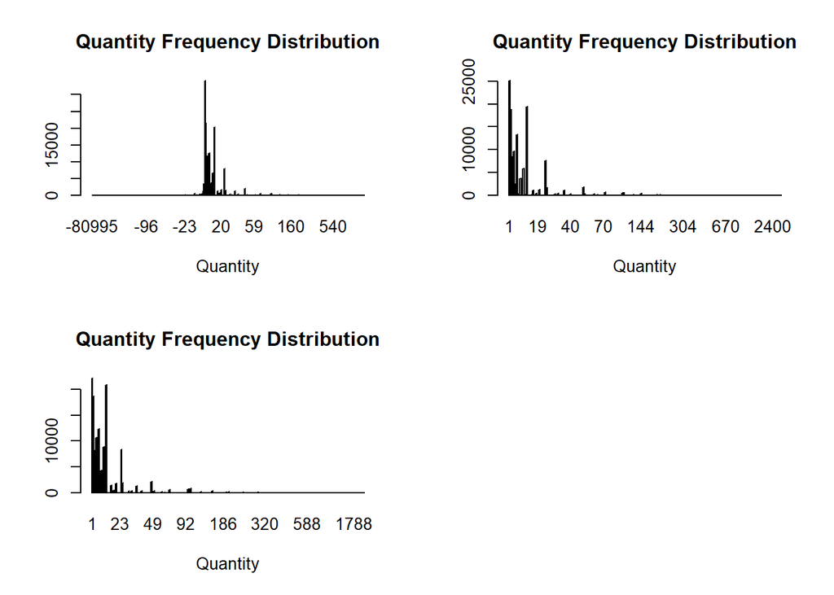

```r
par(mfrow=c(2,2))
clustlabel<- 1
while(clustlabel<K+1){
  clust <- clustDF[clustDF$clusterNum == clustlabel,]

  counts <- table(clust$Quantity)

  b <- barplot(counts, main="Quantity Frequency Distribution",
               xlab="Quantity")
  clustlabel<-clustlabel+1
}
par(mfrow=c(1,1))
```

In terms of quantity distribution, Clusters 2 and 3 have similar quantity distributions ranging from 1-15. Whereas, Cluster 1 has quantity distribution in the negative range and this is not valid. The positive range is slightly higher than the other 2 clusters.

```r
cat("\nUnitPrice distribution comparison per cluster\n")
```

```
##
## UnitPrice distribution comparison per cluster
```

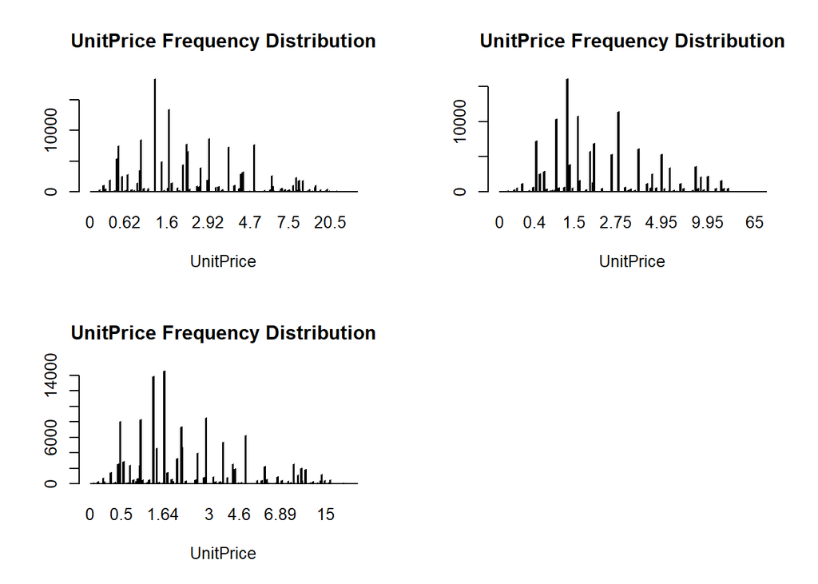

```r
par(mfrow=c(2,2))
clustlabel<- 1
while(clustlabel<K+1){

  clust <- clustDF[clustDF$clusterNum ==clustlabel,]

  counts <- table(clust$UnitPrice)

  b <- barplot(counts, main="UnitPrice Frequency Distribution",
               xlab="UnitPrice")

  clustlabel<-clustlabel+1

}
par(mfrow=c(1,1))
```

The UnitPrice is evenly distributed in all the 3 clusters as supported by the summary statistics # earlier. The common UnitPrice among the clusters still seems to be 1.25.

```r
cat("\nInvoiceYear distribution comparison per cluster\n")
```

```
##
## InvoiceYear distribution comparison per cluster
```

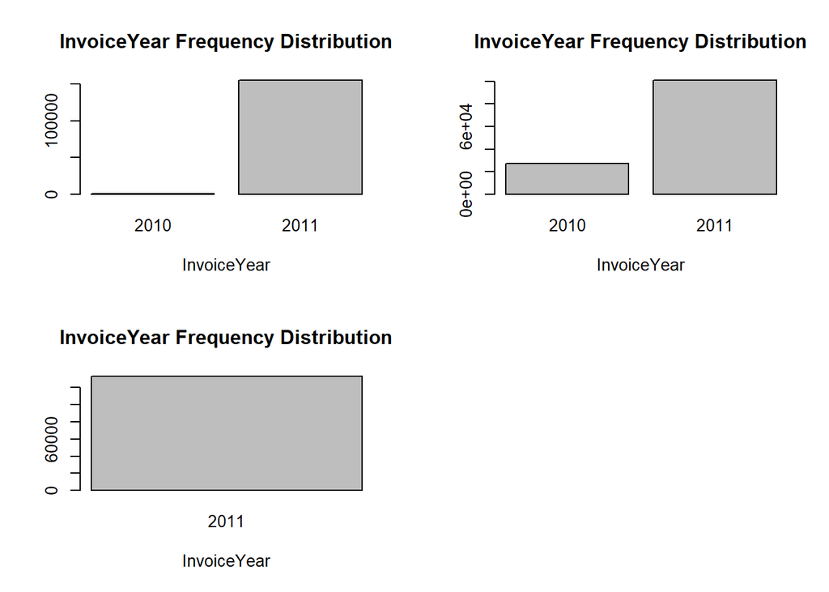

```r
par(mfrow=c(2,2))
clustlabel<- 1
while(clustlabel<K+1){

  clust <- clustDF[clustDF$clusterNum ==clustlabel,]

  counts <- table(clust$InvoiceYear)

  b <- barplot(counts, main="InvoiceYear Frequency Distribution",
               xlab="InvoiceYear")

  clustlabel<-clustlabel+1

}
par(mfrow=c(1,1))
```

Cluster 3 contains data from 2011 only, whereas Clusters 1 and 2 have a mixture of data from 2010 and 2011 too. Cluster 2 has a greater number of invoices from 2010 in comparison to Cluster 1.

```r
cat("\nInvoiceMonth distribution comparison per cluster\n")
```

```
##
## InvoiceMonth distribution comparison per cluster
```

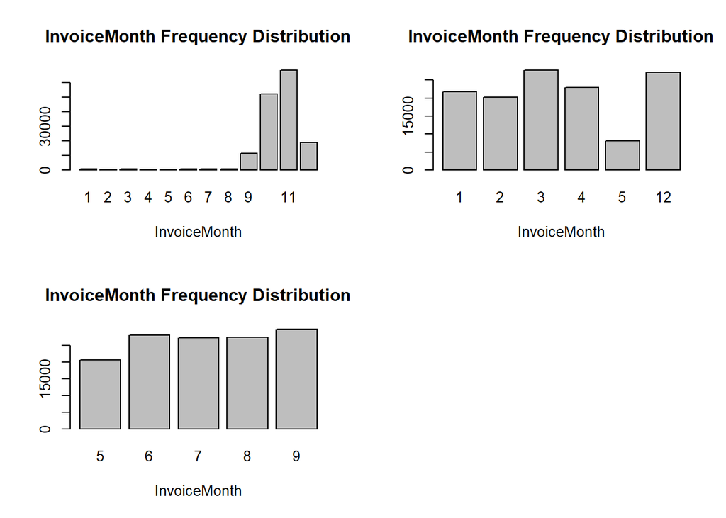

```r
par(mfrow=c(2,2))
clustlabel<- 1
while(clustlabel<K+1){

  clust <- clustDF[clustDF$clusterNum ==clustlabel,]

  counts <- table(clust$InvoiceMonth)

  b <- barplot(counts, main="InvoiceMonth Frequency Distribution",
               xlab="InvoiceMonth")

  clustlabel<-clustlabel+1

}
par(mfrow=c(1,1))
```

The distribution here is pretty interesting as there is no common pattern here and the individual clusters can be seen.

Cluster 1 shows high frequency in October and November. However it does have some overlaps with Cluster 2 for the month of December and Cluster 3 for the month of September for some points. The higher number of purchases in the last few months of the year can be accounted for the fact that the festive period such as Christmas is around the corner in the UK.

Cluster 2 shows high frequency in March and December. It does contain some points in the earlier months of the year from January to May.

Cluster 3 shows high frequency in the months from June to September. It does contain some points in the months of May too.

However it does have overlaps with Cluster 1 for the month of September and Cluster 2 for the month of May for some points.

The overlaps could be the points that lie in between the clusters and other factors need to be taken in consideration as well.

```r
cat("\nInvoiceDay distribution comparison per cluster\n")
```

```
##
## InvoiceDay distribution comparison per cluster
```

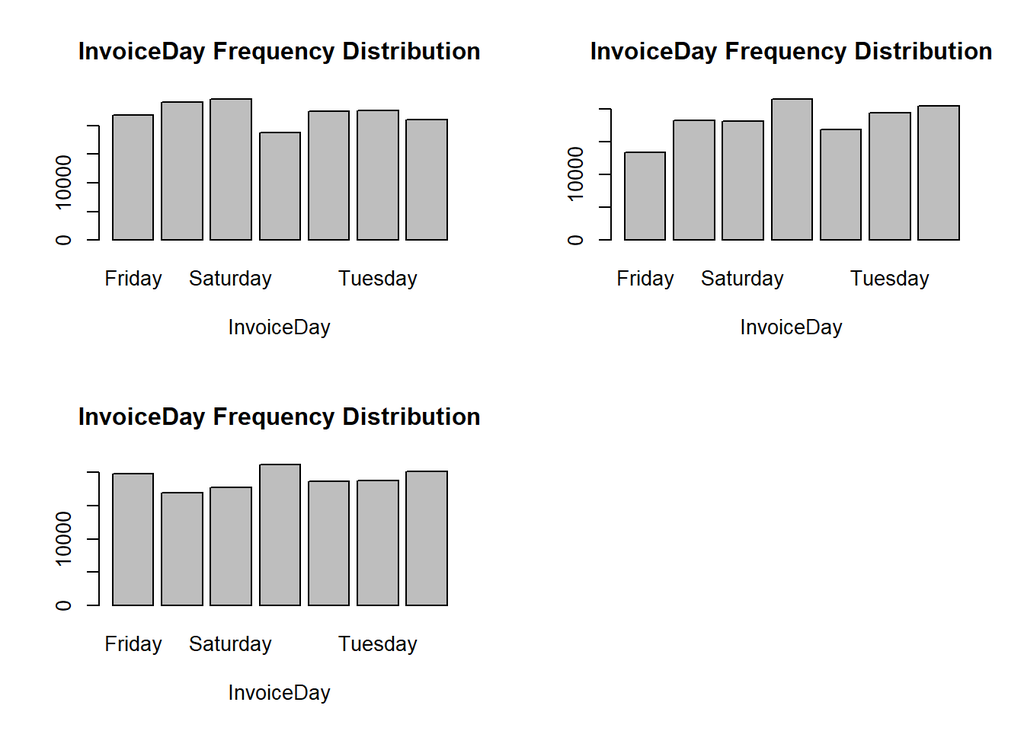

```r
par(mfrow=c(2,2))
clustlabel<- 1
while(clustlabel<K+1){

  clust <- clustDF[clustDF$clusterNum ==clustlabel,]

  counts <- table(clust$InvoiceDay)

  b <- barplot(counts, main="InvoiceDay Frequency Distribution",
               xlab="InvoiceDay")

  clustlabel<-clustlabel+1

}
par(mfrow=c(1,1))
```

The frequency of purchases is somewhat uniquely distributed in all the clusters.

Cluster 1: Saturday

Cluster 2: Sunday

Cluster 3: Sunday

This explains that this is an important factor in the market segmentation of the clusters. With more information known about the demographics of the clusters, more can be inferred and the marketing strategies can be catered accordingly.

For example, weekend sales will prove to be beneficial and can result in more purchases. Another marketing strategy is to ensure the stocks are replenished before the weekend starts.

All in all, the month and the day help to easily identify which cluster the data point is likely to be clustered into.

They have proven to be strong variables to separate clusters.

Top 10 products in every cluster

```r
# install.packages("dplyr")
library("dplyr")
require(dplyr)

clustlabel<- 1
while (clustlabel<K+1){
clust <- clustDF[clustDF$clusterNum ==clustlabel,]
cat('\nTop 10 products bought by the customers by quantity in cluster',clustlabel,'\n')
top10 <- clust %>% group_by(Description) %>% summarise(Quantity = sum(Quantity)) %>% arrange(desc(Quantity))
print(head(top10,10))
clustlabel <- clustlabel +1
}
```

```
##
## Top 10 products bought by the customers by quantity in cluster 1
## # A tibble: 10 x 2
##    Description                         Quantity
##    <fct>                                  <int>
##  1 RABBIT NIGHT LIGHT                     22353
##  2 POPCORN HOLDER                         20663
##  3 WORLD WAR 2 GLIDERS ASSTD DESIGNS      14082
##  4 ASSTD DESIGN 3D PAPER STICKERS         12600
##  5 JUMBO BAG RED RETROSPOT                11796
##  6 "PAPER CHAIN KIT 50'S CHRISTMAS "      10591
##  7 ASSORTED COLOUR BIRD ORNAMENT          10045
##  8 WOODEN STAR CHRISTMAS SCANDINAVIAN      9000
##  9 WOODEN HEART CHRISTMAS SCANDINAVIAN     8839
## 10 DISCO BALL CHRISTMAS DECORATION         8530
##
## Top 10 products bought by the customers by quantity in cluster 2
## # A tibble: 10 x 2
##    Description                        Quantity
##    <fct>                                 <int>
##  1 MEDIUM CERAMIC TOP STORAGE JAR        74215
##  2 WORLD WAR 2 GLIDERS ASSTD DESIGNS     25108
##  3 WHITE HANGING HEART T-LIGHT HOLDER    17914
##  4 PACK OF 72 RETROSPOT CAKE CASES       16303
##  5 JUMBO BAG RED RETROSPOT               15284
##  6 "PACK OF 12 LONDON TISSUES "          11644
##  7 ASSORTED COLOUR BIRD ORNAMENT         11234
##  8 SMALL POPCORN HOLDER                  10777
##  9 GROW A FLYTRAP OR SUNFLOWER IN TIN    10419
## 10 "MINI PAINT SET VINTAGE "             10009
##
## Top 10 products bought by the customers by quantity in cluster 3
## # A tibble: 10 x 2
##    Description                        Quantity
##    <fct>                                 <int>
##  1 JUMBO BAG RED RETROSPOT               18192
##  2 ASSORTED COLOUR BIRD ORNAMENT         14233
##  3 WORLD WAR 2 GLIDERS ASSTD DESIGNS     14217
##  4 PACK OF 72 RETROSPOT CAKE CASES       12475
##  5 PACK OF 60 PINK PAISLEY CAKE CASES    11408
##  6 "GIRLS ALPHABET IRON ON PATCHES "     11232
##  7 WHITE HANGING HEART T-LIGHT HOLDER    11107
##  8 ASSORTED COLOURS SILK FAN             10980
##  9 POPCORN HOLDER                         9865
## 10 "BROCADE RING PURSE "                  9676
```

Items that have been purchased the most in every cluster:

Cluster1: RABBIT NIGHT LIGHT Quantity = 22353

Cluster2: MEDIUM CERAMIC TOP STORAGE JAR Quantity = 74215

Cluster3: JUMBO BAG RED RETROSPOT Quantity = 18192

We also notice that WORLD WAR 2 GLIDERS ASSTD DESIGNS appears 3rd in Cluster1, 2nd in Cluster2, 3rd in Cluster3.

World War2 Glider Asstd Designs appears within Top5 in all Clusters. We also notice that JUMBO BAG RED RETROSPOT appears 5th in Cluster1, 5th in Cluster2, 1st in Cluster3.

Hence,we conclude that WORLD WAR 2 GLIDERS ASSTD DESIGNS,JUMBO BAG RED RETROSPOT and ASSORTED COLOUR BIRD ORNAMENT are the most well-liked products overall since it appears in all 3 clusters.

When comparing these 3 clusters with 4 clusters for Quantity, the top product for the 3 clusters is the same as the top product for 3 out of 4 clusters in K=4.

One marketing strategy would be to replenish these stocks of WORLD WAR 2 GLIDERS ASSTD DESIGNS,JUMBO BAG RED RETROSPOT and ASSORTED COLOUR BIRD ORNAMENT frequently and ensure they are always available.

Introducing new variable Sales = Quantity * UnitPrice

```r
clustDF$Sales <- clustDF$Quantity * clustDF$UnitPrice
head(clustDF)
```

```
##   InvoiceNo_num StockCode_num Description_num Quantity_num UnitPrice_num
## 1             1          1663            3235            2          7.65
## 2             1          2795            4035            6          3.39
## 3             1          2985            2980            6          3.39
## 4             1          2986            1959            6          3.39
## 5             1          3045             932            8          2.75
## 6             1          3538            4027            6          2.55
##   CustomerID_num InvoiceYear_num InvoiceMonth_num InvoiceDay_num InvoiceNo
## 1           4040            2010               12              2    536365
## 2           4040            2010               12              2    536365
## 3           4040            2010               12              2    536365
## 4           4040            2010               12              2    536365
## 5           4040            2010               12              2    536365
## 6           4040            2010               12              2    536365
##   StockCode                         Description Quantity UnitPrice
## 1     22752        SET 7 BABUSHKA NESTING BOXES        2      7.65
## 2     71053                 WHITE METAL LANTERN        6      3.39
## 3    84029E      RED WOOLLY HOTTIE WHITE HEART.        6      3.39
## 4    84029G KNITTED UNION FLAG HOT WATER BOTTLE        6      3.39
## 5    84406B      CREAM CUPID HEARTS COAT HANGER        8      2.75
## 6    85123A  WHITE HANGING HEART T-LIGHT HOLDER        6      2.55
##   CustomerID InvoiceYear InvoiceMonth InvoiceDay clusterNum Sales
## 1      17850        2010           12     Monday          2 15.30
## 2      17850        2010           12     Monday          2 20.34
## 3      17850        2010           12     Monday          2 20.34
## 4      17850        2010           12     Monday          2 20.34
## 5      17850        2010           12     Monday          2 22.00
## 6      17850        2010           12     Monday          2 15.30
```

```r
clustlabel<- 1
while (clustlabel<K+1){
clust <- clustDF[clustDF$clusterNum ==clustlabel,]
cat('\nTop 10 products bought by the customers by Sales in cluster',clustlabel,'\n')
top10 <- clust %>% group_by(Description) %>% summarise(Sales = sum(Sales)) %>% arrange(desc(Sales))
print(head(top10,10))

clustlabel <- clustlabel +1
}
```

```
##
## Top 10 products bought by the customers by Sales in cluster 1
## # A tibble: 10 x 2
##    Description                        Sales
##    <fct>                              <dbl>
##  1 RABBIT NIGHT LIGHT                42195.
##  2 "PAPER CHAIN KIT 50'S CHRISTMAS " 29075.
##  3 JUMBO BAG RED RETROSPOT           22340.
##  4 DOORMAT KEEP CALM AND COME IN     20069.
##  5 REGENCY CAKESTAND 3 TIER          19700.
##  6 HOT WATER BOTTLE KEEP CALM        19331.
##  7 ASSORTED COLOUR BIRD ORNAMENT     16112.
##  8 CHILLI LIGHTS                     16082.
##  9 POPCORN HOLDER                    15618.
## 10 BLACK RECORD COVER FRAME          15275.
##
## Top 10 products bought by the customers by Sales in cluster 2
## # A tibble: 10 x 2
##    Description                         Sales
##    <fct>                               <dbl>
##  1 MEDIUM CERAMIC TOP STORAGE JAR     77184.
##  2 REGENCY CAKESTAND 3 TIER           68299.
##  3 WHITE HANGING HEART T-LIGHT HOLDER 47958.
##  4 JUMBO BAG RED RETROSPOT            27024.
##  5 PARTY BUNTING                      24013.
##  6 ASSORTED COLOUR BIRD ORNAMENT      18206.
##  7 CHILLI LIGHTS                      17909.
##  8 VINTAGE UNION JACK MEMOBOARD       17251.
##  9 WOOD BLACK BOARD ANT WHITE FINISH  15619.
## 10 FAIRY CAKE FLANNEL ASSORTED COLOUR 14117.
##
## Top 10 products bought by the customers by Sales in cluster 3
## # A tibble: 10 x 2
##    Description                          Sales
##    <fct>                                <dbl>
##  1 REGENCY CAKESTAND 3 TIER            45477.
##  2 PICNIC BASKET WICKER 60 PIECES      39620.
##  3 PARTY BUNTING                       37297.
##  4 JUMBO BAG RED RETROSPOT             34233.
##  5 WHITE HANGING HEART T-LIGHT HOLDER  30868.
##  6 SPOTTY BUNTING                      25757.
##  7 ASSORTED COLOUR BIRD ORNAMENT       22516.
##  8 "REGENCY TEAPOT ROSES "             19556.
##  9 SET OF TEA COFFEE SUGAR TINS PANTRY 18021.
## 10 SET OF 3 REGENCY CAKE TINS          17200.
```

Items that garnered highest sales:

Cluster1:RABBIT NIGHT LIGHT Sales= 42195

Cluster2:MEDIUM CERAMIC TOP STORAGE JAR Sales=77184

Cluster3:REGENCY CAKESTAND 3 TIER Sales= 45477

REGENCY CAKESTAND 3 TIER is 5th in Cluster1, 2nd in Cluster2, 1st in Cluster3. It appears within Top5 in 3 Clusters.

Hence, it can be concluded that it is one of the important items that bring about the highest sales for the store.

JUMBO BAG RED RETROSPOT and ASSORTED COLOUR BIRD ORNAMENT appears in Top10 for all the clusters.

Therefore, we conclude that REGENCY CAKESTAND 3 TIER,JUMBO BAG RED RETROSPOT, ASSORTED COLOUR BIRD ORNAMENT are products that garner the highest sales for the store overall.

Except for Cluster3, the top products for Quantity remains the top product for sales as well.

One marketing Strategy would be to have products that are similar in function as of those that garner highest sales. So that in case these products are not available, there will be substitute products to replace them.

In conclusion, there are some products that have topped the frequency list for both k=3 and k=4. These products are JUMBO BAG RED RETROSPOT and WORLD WAR 2 GLIDERS ASSTD DESIGNS in terms of quantity.

In terms of sales, the same products have topped for both k=3 and k=4 except for WHITE HANGING HEART T-LIGHT HOLDERS.

Overall, after looking at the different clusters using 2 different k -values, we have decided that k=3 addresses the hypothesis better because segmenting the data into another cluster was unnecessary in our case.

This can be seen from Clusters 2 and 3 from k=4 that are very similar to each other. The similarity is being shown by common products such as JUMBO BAG RED RETROSPORT, MINI PAINT SET VINTAGE, WORLD WAR 2 GLIDERS ASST DESIGNS, PACK OF 72 and RETROSPORT CAKE CASES.